# R과 RStudio의 소개

연규필

#### 학습목표: R과 RStudio의 기본 구조와 환경을 살펴보고 기초적인 사용법을 익힌다.

# 1 . R 프로그램

#### - 데이터 조작, 통계분석, 컴퓨팅 및 자료의 시각화를 위한 공개용 프로그래밍 언어

#### - 1993년 뉴질랜드 오클랜드 대학의 통계학과 교수 2명 (Ross Ihaka, Robert Gentleman)이 개발함

#### - Window, Mac, Linux에서 모두 작동하는 특징으로 최근 Data Science 분야에서 널리 활용되고 있음

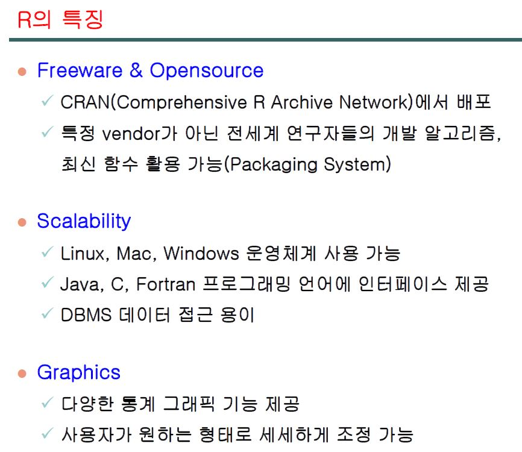

## 1.1 R download

#### - https://www.r-project.org 또는 https://cran.r-project.org

#### - CRAN 지역선택 (Korea를 찾아 나오는 미러사이트 중 하나를 클릭하면 됨)

#### - 윈도우 시스템인 경우, **Download R for Windows**를 선택

#### - Subdirectory에서 **base**를 선택

#### - **Download R x.x.x for Windows** 클릭

[figure not shown]

## 1.2 R 초기화면

R을 실행하면 다음의 R-GUI 창이 뜨고 내부에 R Console 창이 있는데 여기에 명령어를 입력하고 결과를 얻음

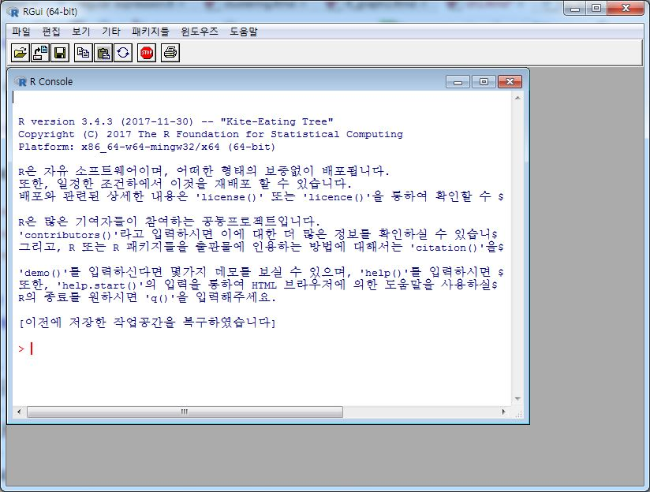

### R 콘솔에서의 명령어 입력 실습

```r
# 숫자의 입력
# 변수명을 타이핑하면 변수의 내용을 보여줌

a = 3
a
```

```
## [1] 3
```

```r
b = 4
b
```

```
## [1] 4
```

```r
# 숫자 변수의 연산
# 여러 명령어를 한줄에 입력할 때는 세미콜론(;)으로 구분

a+b; a-b; a*b; a/b
```

```
## [1] 7
## [1] -1
## [1] 12
## [1] 0.75
```

```r
# 문자의 입력

text ="즐거운 R 프로그래밍"
```

```r
text
```

```
## [1] "즐거운 R 프로그래밍"
```

## 1.3 R 편집기 윈도우의 사용

- 파일 -> 새스크립트

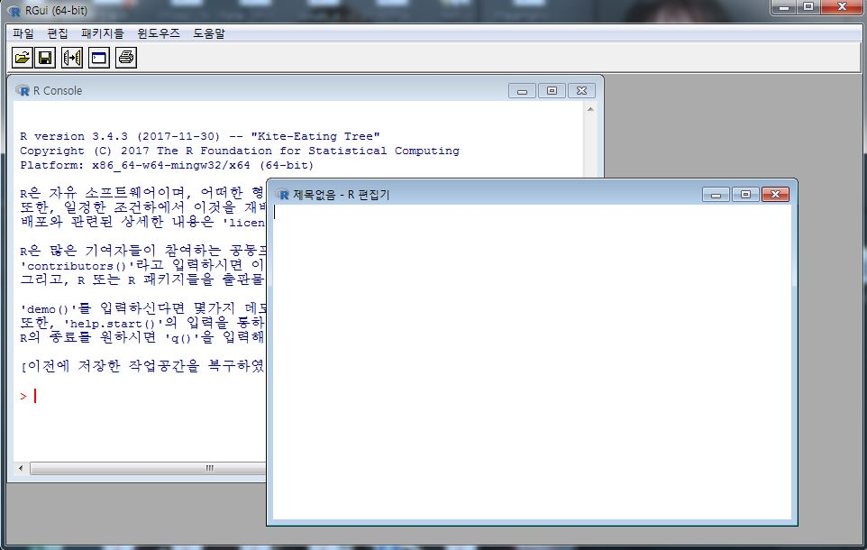

#### 편집기 창에서 다음과 같은 코드를 입력하고 실행시켜 보자

- 편집기 창의 한줄을 실행시키려면 커서를 해당 명령어 라인에 위치시킨 후 Ctrl+r을 누름

```r
Age = c(23,64,66,31,55,48,58,31,27,25)   # 벡터 생성
Age   # 객체의 내용 출력
```

```
##  [1] 23 64 66 31 55 48 58 31 27 25
```

```r
summary(Age)   # 객체에 대한 요약
```

```
##    Min. 1st Qu.  Median    Mean 3rd Qu.    Max.
##   23.00   28.00   39.50   42.80   57.25   66.00
```

```r
Super <- c(40,88,110,86,137,78,111,88,80,86)   # =과 <-는 동일한 기능
Super   # 객체의 내용 출력
```

```
##  [1]  40  88 110  86 137  78 111  88  80  86
```

```r
summary(Super)   # 객체에 대한 요약
```

```
##    Min. 1st Qu.  Median    Mean 3rd Qu.    Max.
##    40.0    81.5    87.0    90.4   104.5   137.0
```

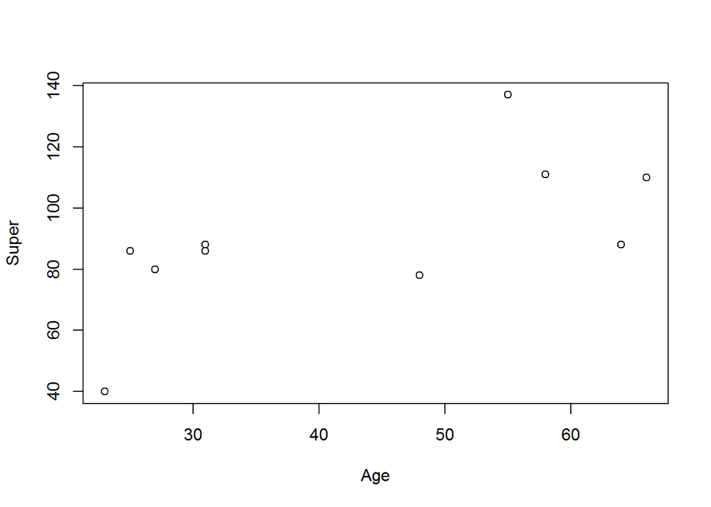

```r
plot(Age,Super)   # 2차원 산점도 작성
```

# 2 . RStudio

- RStudio는 R을 편리하게 사용할수 있도록 해주는 인터페이스
- https://www.rstudio.com/

[figure not shown]

## 2.1 RStudio 초기화면

- 크게 네개의 창으로 구성: 스크립트창, 콘솔창, 환경설정 및 명령어 히스토리 창, 도움말 및 그림 등의 창
- 스크립트창에 프로그램을 코딩하고 실행시키면 콘솔창 또는 그림창에 결과가 나타남
- 스크립트창에 있는 명령어 코드를 실행시킬 때의 단축키: Ctrl+Enter

[figure not shown]

## 2.2 RStudio 살펴보기

### 2.2.1 RStudio 의 기본적인 사용법

- R script 창에서 프로그램 코딩
- 코딩된 프로그램을 실행하면 결과가 Console 창에 나타나고, 그래프는 RStudio 우측 하단의 Plots 창에 나타남
- R script 창에서 실행할 명령어가 있는 줄에 커서를 놓고 Ctrl+Enter를 누르면 해당 명령어가 실행됨
- RStudio 단축키는 Tools -> Keyboard Shortcuts Help

#### 새로운 스크립트 창 열기

[figure not shown]

#### 스크립트 창에 명령어 입력하고 실행하기: Ctrl+Enter

[figure not shown]

### 2.2.2 History 창

#### 우측 상단의 History 창을 보면 현재까지 실행한 명령어 리스트가 있음.

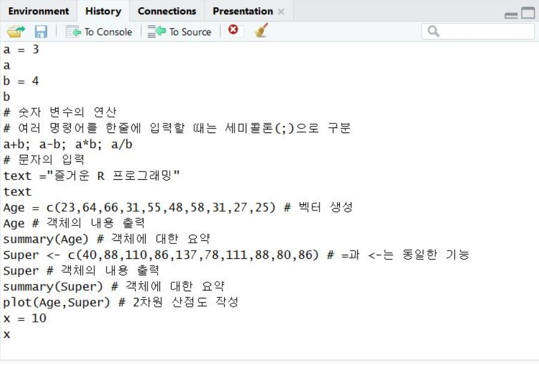

#### History 창의 한 명령행을 더블클릭하면 해당 명령어가 콘솔창에서 실행됨.

## 2.3 RStudio 환경의 옵션 설정

### 2.3.1 General

#### 메뉴에서 Tools -> Global Options 선택하면 Options 창이 열림

#### General 에서는 R version이 최신인지 확인하고, 만약 최신 버전의 R을 새로 설치했다면 Change를 눌러 새버전의 R과 연동시킴

[figure not shown]

### 2.3.2 Code

#### Code 에서는 Editing, Display, Saving, Completion, diagnotics 등의 옵션을 설정함

#### Saving 탭을 눌러 아래 그림에서와 같이 default text encoding인 CP949로 되어있음을 확인

- 파일 저장시 디폴트 인코딩이 CP949임을 의미함.
- 스크립트 파일을 열 때, 저장시 사용한 인코딩으로 다시 열어야 한글이 제대로 보임.
- 스크립트 파일의 한글이 깨질때는 File -> Reopen with Encoding… 에서 encoding 방식을 바꾸어 주자. (보통 UTF-8 또는 CP949)
- 스크립트 파일의 한글이 깨진 상태에서 저장하면 인코딩 방식을 변경해도 한글을 제대로 보이게 하기 어려우므로 주의해야 함.

[figure not shown]

### 2.3.3 Appearance

#### Appearance 에서는 Zoom을 조정하여 RStudio 화면을 확대해 볼 수 있음

#### Font size 를 조정하여 스크립트 창의 글자 크기를 조정 할 수 있음

#### Editor theme에서 원하는 theme을 선택할 수 있음

[figure not shown]

### 2.3.4 Pane Layout

#### Pane Layout 에서는 RStudio 화면 배치를 조정할 수 있음

- Script 창과 Console 창의 위치를 바꾸어 보자.

[figure not shown]

### 2.3.5 Packages

#### Packages에서는 CRAN 미러사이트를 설정하거나 패키지 다운로드 옵션 등을 조정할 수 있음

[figure not shown]

## 2.4 작업폴더(Working Directory) 설정

#### 작업폴더(Working Directory)는 현재 R 세션에서 사용하는 기본 폴더로서 R 소스파일 및 데이터의 저장 및 로딩시 기본이 되는 폴더이다.

- 소스파일이나 데이터를 불러들일 때 작업 폴더에 있는 파일은 경로명을 지정하지 않고 파일명만 사용해도 됨
- 작업폴더가 아닌 곳에 있는 파일을 불러들일 때는 경로명까지 써 주어야함.
- R 데이터를 저장할때도 파일명만 쓰면 기본적으로 작업폴더에 저장되며, 다른 폴더에 저장하기 위해서는 경로명까지 써 주어야 함.

#### Session -> Set Working Directory -> Choose Directory 에서 설정

- 본인이 사용하고자 하는 폴더를 선택하면 됨

[figure not shown]

#### R 콘솔에서 다음과 같은 명령어로 작업폴더를 확인 및 변경할 수도 있다.

```r
getwd() #작업폴더 확인
```

```
## [1] "C:/Lecture_Corp/LG2019/lecture_notes2"
```

```r
setwd("D:/lecture/lecture_note") #작업폴더 변경
```

## 2.5 프로젝트 만들기

#### R 데이터 분석시 소스코드, 이미지, 문서 등의 파일을 효율적으로 관리하기 위한 것으로서 하나의 분석 과제는 하나의 프로젝트로 하여 폴더별로 자료를 관리하면 편리함.

#### 다음과 같은 방식으로 프로젝트를 생성한다.

1. RStudio 우측 상단 Project 버튼 클릭 ( 메뉴에서 File -> New Project 클릭해도 됨)

[figure not shown]

2. [Create Project] 창에서 [New Directory] 선택
- New Directory: 새 프로젝트를 만듦
- Existing Directory: 기존 디엑토리(폴더) 사용
- Version Control: 깃허브(github) 등의 버전 관리 시스템을 이용할 때

[figure not shown]

3. [Project Type] 창에서 [New Project] 선택

[figure not shown]

4. [Create New Project]창에서 프로젝트명과 폴더 지정 후 [Create Project] 버튼 클릭
- [Directory name] 란에 새로 만들 프로젝트명을 입력 (my_project1)
  - 프로젝트명과 폴더경로에는 한글이 들어가지 않도록 할것
- [Create project as subdirectory of]에서 프로젝트 폴더 지정 (D:/)
- 창 왼쪽 하단 [Open in new session]에 체크 (기존 R 스튜디오 창은 그대로 유지한 채 새로운 R 스튜디오 창에 프로젝트를 연다)

[figure not shown]

5. 새프로젝트가 만들어지고 새로운 R 스튜디오 창이 열림
- 콘솔 창 우측 상단 네모 버튼을 클릭하여 스크립트 창도 함께 나타내자.

[figure not shown]

- 우측 하단 Files 창에 D:>my_project1 이라는 프로젝트 폴더 위치가 보임
- 이 폴더에 my_project1.Rproj 라는 프로젝트 파일이 생성되 있음을 알 수 있음
- 윈도우 탐색기에서 위 폴더에 프로젝트 파일이 생성되어 있음을 확인해 볼 것
- 참고로, 프로젝트를 만들면 Working Directory가 프로젝트 폴더로 지정됨

# 3 . R Notebook

#### R 실행결과과 함께 설명을 추가하여 html 또는 pdf 파일 등으로 만들수 있음

- 본 교재도 R Notebook을 통해 만든 파일임.

## 3.1 R Notebook 소스파일

#### 아래 그림처럼 R Notebook을 선택하면 소스파일(.Rmd)이 하나 열림

[figure not shown]

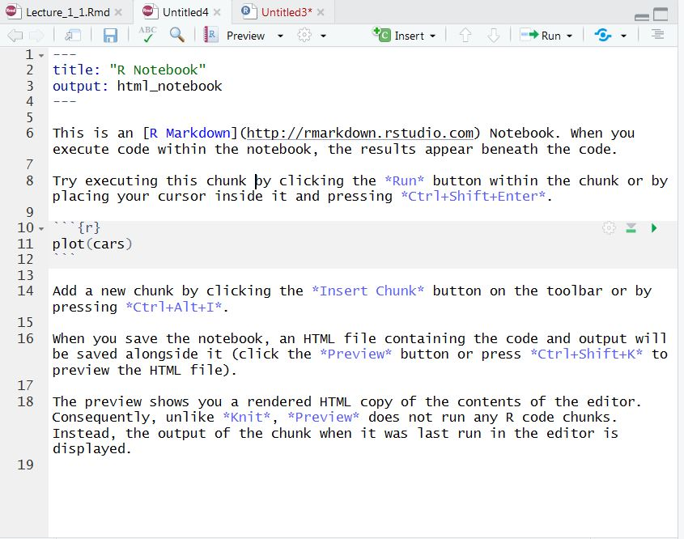

## 3.2 HTML 파일 생성

#### 소스파일 저장 -> R code chunk 실행 -> Preview 클릭

- R code chunk는

  ````
   ```{r}
  ````

  와

  ````
   ```
  ````

  사이에 있는 R 명령어를 말함
- R code chunk 실행을 위해서는 초록색 화살표를 누름
- 소스파일이 저장된 폴더에 소스파일이름.nb.html이 생성되어 있음을 확인

#### 다음과 같은 R 코드가 있는 하나의 chunk를 실행(녹색 화살표 클릭)하면 아래와 같은 결과가 나타남

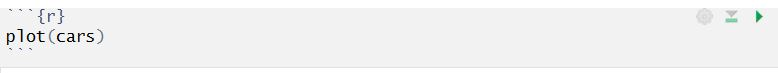

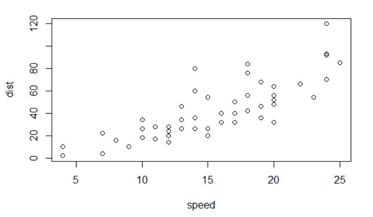

#### 화면 상단 메뉴의 Preview 버튼을 클릭하면 HTML 파일이 생성됨.

[figure not shown]

## 3.3 R Notebook에서의 작업폴더

#### R Notebook에서는 working directory가 소스파일(.Rmd)이 있는 폴더로 강제 지정되며, 앞에서와 같은 방법(setwd())으로는 변경되지 않는다.